# SMS SPAM DETECTION

## Importing Necessary Libraries

```python
import numpy as np
import pandas as pd
```

### Importing the Dataset

```python
df = pd.read_csv('spam.csv', encoding='latin1')
```

Random dataset sample

```python
df.sample(5)
```

|  | v1 | v2 | Unnamed: 2 | Unnamed: 3 | Unnamed: 4 |
| --- | --- | --- | --- | --- | --- |
| 6660 | spam | new medz how t cornel o save on your medlcatio... | NaN | NaN | NaN |
| 516 | spam | Boltblue tones for 150p Reply POLY# or MONO# e... | NaN | NaN | NaN |
| 4432 | ham | Can u look 4 me in da lib i got stuff havent f... | NaN | NaN | NaN |
| 4599 | ham | Hi did u decide wot 2 get 4 his bday if not il... | NaN | NaN | NaN |
| 549 | ham | Ok give me 5 minutes I think I see her. BTW yo... | NaN | NaN | NaN |

Shape of the Dataset

```python
df.shape
```

```
(7515, 5)
```

# Machine Learning Development Life Cycle

## 1. Data Cleaning

## 2. EDA {Exploratory Data Analysis}

## 3. Text Preprocessing

## 4. Model Building

## 5. Model Evaluation

## 6. Model Improvement

## 7. Website Development

## 8. Deployment

## 1. Data Cleaning

Description of the dataset

```python
df.info()
```

```
<class 'pandas.core.frame.DataFrame'>
RangeIndex: 7515 entries, 0 to 7514
Data columns (total 5 columns):
 #   Column      Non-Null Count  Dtype
---  ------      --------------  -----
 0   v1          7515 non-null   object
 1   v2          7515 non-null   object
 2   Unnamed: 2  50 non-null     object
 3   Unnamed: 3  12 non-null     object
 4   Unnamed: 4  6 non-null      object
dtypes: object(5)
memory usage: 293.7+ KB
```

Dropping the last 3 columns

```python
df.drop(columns=['Unnamed: 2','Unnamed: 3','Unnamed: 4'],inplace=True)
```

```python
df.sample(5)
```

|  | v1 | v2 |
| --- | --- | --- |
| 4881 | ham | As usual u can call me ard 10 smth. |
| 5708 | spam | free for business or personal cwfqt start a bu... |
| 1447 | ham | Donâ°Û÷t give a flying monkeys wot they thi... |
| 5407 | ham | Yup he msg me: is tat yijue? Then i tot it's m... |
| 7091 | spam | greetings you are receiving this letter becaus... |

Renaming the columns

```python
df.rename(columns={'v1':'target','v2':'text'},inplace=True)
df.sample(5)
```

|  | target | text |
| --- | --- | --- |
| 2450 | ham | K..give back my thanks. |
| 1517 | spam | Our brand new mobile music service is now live... |
| 3917 | ham | No need to ke qi... ÌÏ too bored izzit y sud... |
| 3762 | ham | K.i will send in &lt;#&gt; min:) |
| 6120 | spam | free ltci policy comparison software long term... |

Converting Label to Numbers for Processing

```python
from sklearn.preprocessing import LabelEncoder
encoder = LabelEncoder()
```

```python
df['target'] = encoder.fit_transform(df['target'])
```

```python
df.head()
```

|  | target | text |
| --- | --- | --- |
| 0 | 0 | Go until jurong point, crazy.. Available only ... |
| 1 | 0 | Ok lar... Joking wif u oni... |
| 2 | 1 | Free entry in 2 a wkly comp to win FA Cup fina... |
| 3 | 0 | U dun say so early hor... U c already then say... |
| 4 | 0 | Nah I don't think he goes to usf, he lives aro... |

### SPAM:1 ,HAM:0

Checking for missing values

```python
df.isnull().sum()
```

```
target    0
text      0
dtype: int64
```

Checking for duplicate values

```python
df.duplicated().sum()
```

```
416
```

Removing duplicates

```python
df = df.drop_duplicates(keep='first')
```

```python
df.duplicated().sum()
```

```
0
```

Shape Of the dataset after Data cleaning

```python
df.shape
```

```
(7099, 2)
```

## 2.EDA

```python
df.head()
```

|  | target | text |
| --- | --- | --- |
| 0 | 0 | Go until jurong point, crazy.. Available only ... |
| 1 | 0 | Ok lar... Joking wif u oni... |
| 2 | 1 | Free entry in 2 a wkly comp to win FA Cup fina... |
| 3 | 0 | U dun say so early hor... U c already then say... |
| 4 | 0 | Nah I don't think he goes to usf, he lives aro... |

```python
df['target'].value_counts()
```

```
0    4597
1    2502
Name: target, dtype: int64
```

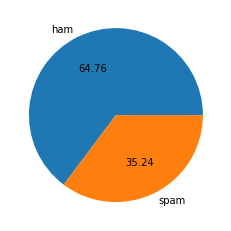

```python
import matplotlib.pyplot as plt
plt.pie(df['target'].value_counts(), labels=['ham','spam'],autopct="%0.2f")
plt.show()
```

### Data is imbalanced .

Finding the number of characters, words and sentenses in the messages for furture analysis.

```python
import nltk
```

```python
nltk.download('punkt')
```

```
True
```

Characters

```python
df['num_characters'] = df['text'].apply(len)
```

```python
df.head()
```

|  | target | text | num_characters |
| --- | --- | --- | --- |
| 0 | 0 | Go until jurong point, crazy.. Available only ... | 111 |
| 1 | 0 | Ok lar... Joking wif u oni... | 29 |
| 2 | 1 | Free entry in 2 a wkly comp to win FA Cup fina... | 155 |
| 3 | 0 | U dun say so early hor... U c already then say... | 49 |
| 4 | 0 | Nah I don't think he goes to usf, he lives aro... | 61 |

Words

```python
df['num_words'] = df['text'].apply(lambda x:len(nltk.word_tokenize(x)))
```

```python
df.head()
```

|  | target | text | num_characters | num_words |
| --- | --- | --- | --- | --- |
| 0 | 0 | Go until jurong point, crazy.. Available only ... | 111 | 24 |
| 1 | 0 | Ok lar... Joking wif u oni... | 29 | 8 |
| 2 | 1 | Free entry in 2 a wkly comp to win FA Cup fina... | 155 | 37 |
| 3 | 0 | U dun say so early hor... U c already then say... | 49 | 13 |
| 4 | 0 | Nah I don't think he goes to usf, he lives aro... | 61 | 15 |

Sentences

```python
df['num_sentences'] = df['text'].apply(lambda x:len(nltk.sent_tokenize(x)))
```

```python
df.head()
```

|  | target | text | num_characters | num_words | num_sentences |
| --- | --- | --- | --- | --- | --- |
| 0 | 0 | Go until jurong point, crazy.. Available only ... | 111 | 24 | 2 |
| 1 | 0 | Ok lar... Joking wif u oni... | 29 | 8 | 2 |
| 2 | 1 | Free entry in 2 a wkly comp to win FA Cup fina... | 155 | 37 | 2 |
| 3 | 0 | U dun say so early hor... U c already then say... | 49 | 13 | 1 |
| 4 | 0 | Nah I don't think he goes to usf, he lives aro... | 61 | 15 | 1 |

Analysing all Messages

```python
df[['num_characters','num_words','num_sentences']].describe()
```

|  | num_characters | num_words | num_sentences |
| --- | --- | --- | --- |
| count | 7099.000000 | 7099.000000 | 7099.000000 |
| mean | 190.223693 | 37.037188 | 1.744894 |
| std | 230.013498 | 40.098059 | 1.307854 |
| min | 2.000000 | 1.000000 | 1.000000 |
| 25% | 43.000000 | 11.000000 | 1.000000 |
| 50% | 93.000000 | 21.000000 | 1.000000 |
| 75% | 165.000000 | 38.000000 | 2.000000 |
| max | 910.000000 | 220.000000 | 38.000000 |

Analysing only Ham Messages

```python
df[df['target'] == 0][['num_characters','num_words','num_sentences']].describe()
```

|  | num_characters | num_words | num_sentences |
| --- | --- | --- | --- |
| count | 4597.000000 | 4597.000000 | 4597.000000 |
| mean | 72.042854 | 17.321732 | 1.827496 |
| std | 57.921165 | 13.572607 | 1.362832 |
| min | 2.000000 | 1.000000 | 1.000000 |
| 25% | 34.000000 | 8.000000 | 1.000000 |
| 50% | 53.000000 | 13.000000 | 1.000000 |
| 75% | 93.000000 | 22.000000 | 2.000000 |
| max | 910.000000 | 220.000000 | 38.000000 |

Analysing only Spam Messages

```python
df[df['target'] == 1][['num_characters','num_words','num_sentences']].describe()
```

|  | num_characters | num_words | num_sentences |
| --- | --- | --- | --- |
| count | 2502.000000 | 2502.000000 | 2502.000000 |
| mean | 407.360911 | 73.260991 | 1.593125 |
| std | 266.733941 | 46.877769 | 1.185647 |
| min | 3.000000 | 1.000000 | 1.000000 |
| 25% | 153.000000 | 30.000000 | 1.000000 |
| 50% | 348.500000 | 62.000000 | 1.000000 |
| 75% | 720.750000 | 123.000000 | 2.000000 |
| max | 829.000000 | 196.000000 | 9.000000 |

### Spam Mesages are longer than Ham messages from our Analysis

### Visualizing our Conclusion

```python
import seaborn as sns
```

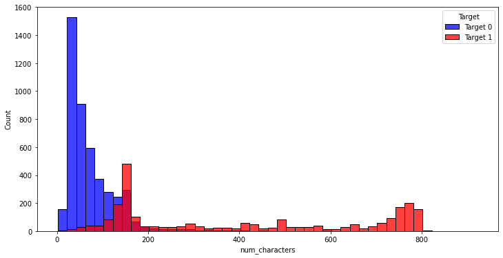

```python
plt.figure(figsize=(12,6))
bin_range = (df['num_characters'].min(), df['num_characters'].max())
bin_width = 20  # You can adjust this value based on your data's spread
sns.histplot(df[df['target'] == 0]['num_characters'], color='blue', binwidth=bin_width, binrange=bin_range, label='Target 0')
sns.histplot(df[df['target'] == 1]['num_characters'], color='red', binwidth=bin_width, binrange=bin_range, label='Target 1')
plt.legend(title='Target')
plt.show()
```

HAM:Blue, SPAM:Red

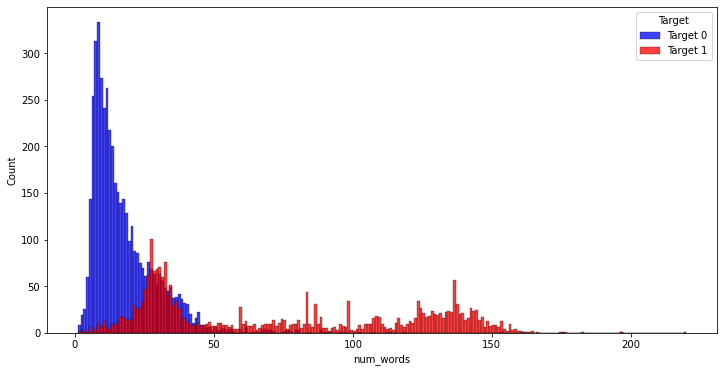

```python
plt.figure(figsize=(12,6))
bin_range = (df['num_words'].min(), df['num_words'].max())
bin_width = 1
sns.histplot(df[df['target'] == 0]['num_words'], color='blue', binwidth=bin_width, binrange=bin_range, label='Target 0')
sns.histplot(df[df['target'] == 1]['num_words'], color='red', binwidth=bin_width, binrange=bin_range, label='Target 1')
plt.legend(title='Target')
plt.show()
```

HAM:Blue, SPAM:Red

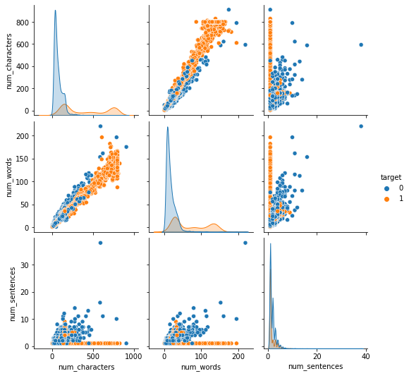

```python
sns.pairplot(df,hue='target')
```

### Correlations between lables

```python
df.corr()
```

|  | target | num_characters | num_words | num_sentences |
| --- | --- | --- | --- | --- |
| target | 1.000000 | 0.696495 | 0.666512 | -0.085617 |
| num_characters | 0.696495 | 1.000000 | 0.988581 | -0.137227 |
| num_words | 0.666512 | 0.988581 | 1.000000 | -0.073256 |
| num_sentences | -0.085617 | -0.137227 | -0.073256 | 1.000000 |

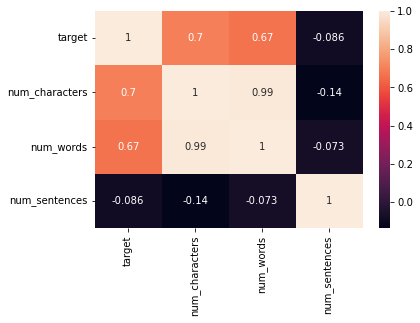

```python
sns.heatmap(df.corr(),annot=True)
```

```python
df.to_csv('DataAnalysis.csv', index=False)
```

## 3. Data Preprocessing

- Lower case
- Tokenization
- Removing special characters
- Removing stop words and punctuation
- Stemming

### List of stopwords in English that doesn't contribute to sentence meaning but are only used in sentence formation.

```python
from nltk.corpus import stopwords
stopwords.words('english')
```

```
['i',
 'me',
 'my',
 'myself',
 'we',
 'our',
 'ours',
 'ourselves',
 'you',
 "you're",
 "you've",
 "you'll",
 "you'd",
 'your',
 'yours',
 'yourself',
 'yourselves',
 'he',
 'him',
 'his',
 'himself',
 'she',
 "she's",
 'her',
 'hers',
 'herself',
 'it',
 "it's",
 'its',
 'itself',
 'they',
 'them',
 'their',
 'theirs',
 'themselves',
 'what',
 'which',
 'who',
 'whom',
 'this',
```

[output cut: 124 more lines]

```
 "mustn't",
 'needn',
 "needn't",
 'shan',
 "shan't",
 'shouldn',
 "shouldn't",
 'wasn',
 "wasn't",
 'weren',
 "weren't",
 'won',
 "won't",
 'wouldn',
 "wouldn't"]
```

### Punctuation marks

```python
import string
string.punctuation
```

```
'!"#$%&\'()*+,-./:;<=>?@[\\]^_`{|}~'
```

### Stemming Process

```python
from nltk.stem.porter import PorterStemmer
ps = PorterStemmer()
ps.stem('driving')
```

```
'drive'
```

## Fnction to perform Text Preprocessing

```python
def transform_text(text):
    text = text.lower()
    text = nltk.word_tokenize(text)

    y = []
    for i in text:
        if i.isalnum():
            y.append(i)

    text = y[:]
    y.clear()

    for i in text:
        if i not in stopwords.words('english') and i not in string.punctuation:
            y.append(i)

    text = y[:]
    y.clear()

    for i in text:
        y.append(ps.stem(i))


    return " ".join(y)
```

### Example of Text Preprocessing

```python
transform_text("""
🎉🎉 Congratulations! You've been selected as the lucky winner of our exclusive giveaway! 🎉🎉

Claim your prize now by clicking on the link below:
👉👉 https://www.amazon.com/

Don't miss out on this amazing opportunity to win big! Hurry, before it's too late!""")
```

```
'congratul select lucki winner exclus giveaway claim prize click link http miss amaz opportun win big hurri late'
```

```python
transform_text("""
Hi there,
We hope this message finds you well. We wanted to reach out to inform you about an exciting opportunity we have available. Our team is conducting a research experiment and we would greatly appreciate your participation.
""")
```

```
'hi hope messag find well want reach inform excit opportun avail team conduct research experi would greatli appreci particip'
```

```python
transform_text("I'm gonna be home soon and i don't want to talk about this stuff anymore tonight, k? I've cried enough today.")
```

```
'gon na home soon want talk stuff anymor tonight k cri enough today'
```

Adding a feature called transformed text to the dataframe

```python
df['transformed_text'] = df['text'].apply(transform_text)
```

```python
df.head()
```

|  | target | text | num_characters | num_words | num_sentences | transformed_text |
| --- | --- | --- | --- | --- | --- | --- |
| 0 | 0 | Go until jurong point, crazy.. Available only ... | 111 | 24 | 2 | go jurong point crazi avail bugi n great world... |
| 1 | 0 | Ok lar... Joking wif u oni... | 29 | 8 | 2 | ok lar joke wif u oni |
| 2 | 1 | Free entry in 2 a wkly comp to win FA Cup fina... | 155 | 37 | 2 | free entri 2 wkli comp win fa cup final tkt 21... |
| 3 | 0 | U dun say so early hor... U c already then say... | 49 | 13 | 1 | u dun say earli hor u c alreadi say |
| 4 | 0 | Nah I don't think he goes to usf, he lives aro... | 61 | 15 | 1 | nah think goe usf live around though |

### WordCloud

```python
from wordcloud import WordCloud
wc = WordCloud(width=500,height=500,min_font_size=10,background_color='white')
```

#### Most Common Words in a Spam Messages

```python
wc.generate(df[df['target'] == 1]['transformed_text'].str.cat(sep=" "))
```

```
<wordcloud.wordcloud.WordCloud at 0x2256176b580>
```

```python
spam_wc = wc.generate(df[df['target'] == 1]['transformed_text'].str.cat(sep=" "))
```

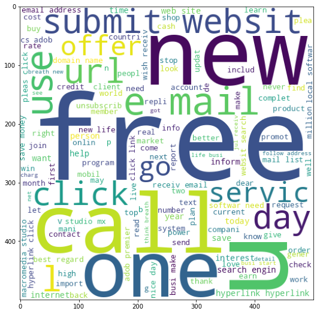

```python
plt.figure(figsize=(15,9))
plt.imshow(spam_wc)
```

```python
ham_wc = wc.generate(df[df['target'] == 0]['transformed_text'].str.cat(sep=" "))
```

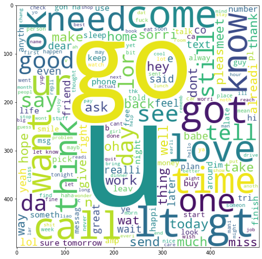

```python
plt.figure(figsize=(15,9))
plt.imshow(ham_wc)
```

```python
df.head()
```

|  | target | text | num_characters | num_words | num_sentences | transformed_text |
| --- | --- | --- | --- | --- | --- | --- |
| 0 | 0 | Go until jurong point, crazy.. Available only ... | 111 | 24 | 2 | go jurong point crazi avail bugi n great world... |
| 1 | 0 | Ok lar... Joking wif u oni... | 29 | 8 | 2 | ok lar joke wif u oni |
| 2 | 1 | Free entry in 2 a wkly comp to win FA Cup fina... | 155 | 37 | 2 | free entri 2 wkli comp win fa cup final tkt 21... |
| 3 | 0 | U dun say so early hor... U c already then say... | 49 | 13 | 1 | u dun say earli hor u c alreadi say |
| 4 | 0 | Nah I don't think he goes to usf, he lives aro... | 61 | 15 | 1 | nah think goe usf live around though |

## Most Common Words in a Spam Message

```python
spam_corpus = []
for msg in df[df['target'] == 1]['transformed_text'].tolist():
    for word in msg.split():
        spam_corpus.append(word)
```

```python
len(spam_corpus)
```

```
113846
```

```python
from collections import Counter
pd.DataFrame(Counter(spam_corpus).most_common(50))
```

|  | 0 | 1 |
| --- | --- | --- |
| 0 | 1635465 | 1412 |
| 1 | free | 702 |
| 2 | get | 646 |
| 3 | com | 536 |
| 4 | mail | 524 |
| 5 | receiv | 512 |
| 6 | 1 | 508 |
| 7 | click | 506 |
| 8 | offer | 497 |
| 9 | busi | 487 |
| 10 | call | 474 |
| 11 | new | 444 |
| 12 | email | 437 |
| 13 | 2 | 433 |
| 14 | websit | 425 |
| 15 | compani | 423 |
| 16 | http | 422 |
| 17 | pleas | 421 |
| 18 | one | 416 |
| 19 | 5 | 401 |
| 20 | adob | 390 |
| 21 | softwar | 382 |
| 22 | e | 378 |
| 23 | inform | 374 |
| 24 | make | 368 |
| 25 | site | 362 |
| 26 | time | 361 |
| 27 | hyperlink | 360 |
| 28 | want | 343 |
| 29 | market | 341 |
| 30 | messag | 340 |
| 31 | need | 339 |
| 32 | price | 321 |
| 33 | like | 319 |
| 34 | url | 316 |
| 35 | day | 311 |
| 36 | save | 310 |
| 37 | best | 308 |
| 38 | 3 | 305 |
| 39 | list | 304 |
| 40 | money | 297 |
| 41 | use | 292 |
| 42 | custom | 288 |
| 43 | us | 288 |
| 44 | onlin | 281 |
| 45 | servic | 268 |
| 46 | order | 260 |
| 47 | l | 256 |
| 48 | rate | 251 |
| 49 | work | 251 |

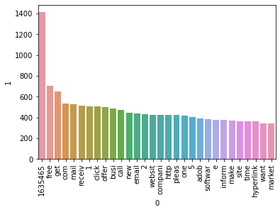

```python
sns.barplot(pd.DataFrame(Counter(spam_corpus).most_common(30))[0],pd.DataFrame(Counter(spam_corpus).most_common(30))[1])
plt.xticks(rotation='vertical')
plt.show()
```

### Most Common Words in a Ham Message

```python
ham_corpus = []
for msg in df[df['target'] == 0]['transformed_text'].tolist():
    for word in msg.split():
        ham_corpus.append(word)
```

```python
len(ham_corpus)
```

```
36424
```

```python
pd.DataFrame(Counter(ham_corpus).most_common(50))
```

|  | 0 | 1 |
| --- | --- | --- |
| 0 | u | 891 |
| 1 | go | 405 |
| 2 | get | 351 |
| 3 | gt | 288 |
| 4 | lt | 287 |
| 5 | 2 | 285 |
| 6 | come | 275 |
| 7 | call | 258 |
| 8 | know | 239 |
| 9 | got | 236 |
| 10 | like | 234 |
| 11 | time | 222 |
| 12 | love | 216 |
| 13 | ok | 215 |
| 14 | good | 213 |
| 15 | want | 208 |
| 16 | ur | 200 |
| 17 | day | 192 |
| 18 | need | 170 |
| 19 | one | 166 |
| 20 | lor | 159 |
| 21 | 4 | 156 |
| 22 | home | 152 |
| 23 | think | 149 |
| 24 | see | 147 |
| 25 | take | 144 |
| 26 | still | 143 |
| 27 | da | 142 |
| 28 | tell | 133 |
| 29 | make | 130 |
| 30 | today | 128 |
| 31 | say | 127 |
| 32 | back | 127 |
| 33 | ask | 123 |
| 34 | send | 123 |
| 35 | n | 122 |
| 36 | hope | 122 |
| 37 | sorri | 122 |
| 38 | work | 120 |
| 39 | r | 120 |
| 40 | dont | 118 |
| 41 | meet | 112 |
| 42 | hi | 112 |
| 43 | well | 109 |
| 44 | thing | 109 |
| 45 | wat | 108 |
| 46 | k | 107 |
| 47 | much | 107 |
| 48 | night | 107 |
| 49 | oh | 106 |

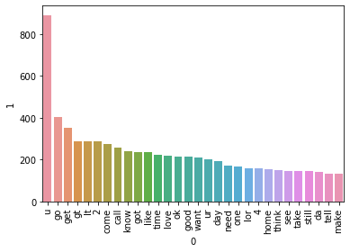

```python
from collections import Counter
sns.barplot(pd.DataFrame(Counter(ham_corpus).most_common(30))[0],pd.DataFrame(Counter(ham_corpus).most_common(30))[1])
plt.xticks(rotation='vertical')
plt.show()
```

```python
df.head()
```

|  | target | text | num_characters | num_words | num_sentences | transformed_text |
| --- | --- | --- | --- | --- | --- | --- |
| 0 | 0 | Go until jurong point, crazy.. Available only ... | 111 | 24 | 2 | go jurong point crazi avail bugi n great world... |
| 1 | 0 | Ok lar... Joking wif u oni... | 29 | 8 | 2 | ok lar joke wif u oni |
| 2 | 1 | Free entry in 2 a wkly comp to win FA Cup fina... | 155 | 37 | 2 | free entri 2 wkli comp win fa cup final tkt 21... |
| 3 | 0 | U dun say so early hor... U c already then say... | 49 | 13 | 1 | u dun say earli hor u c alreadi say |
| 4 | 0 | Nah I don't think he goes to usf, he lives aro... | 61 | 15 | 1 | nah think goe usf live around though |

## 4. Model Building

### Naïve Bayes Classifier

##### The Naïve Bayes classifier is a supervised machine learning algorithm, which is used for classification tasks, like text classification.

Vectorization Text Vectorization using Bag of Words tfidf vectorization {Term frequency Inverse document frequency (TFIDF) }

```python
from sklearn.feature_extraction.text import CountVectorizer,TfidfVectorizer
cv = CountVectorizer()
tfidf = TfidfVectorizer(max_features=3000)
```

```python
X = tfidf.fit_transform(df['transformed_text']).toarray()
```

```python
# Experimentation:
#from sklearn.preprocessing import MinMaxScaler
#scaler = MinMaxScaler()
#X = scaler.fit_transform(X)
# appending the num_character col to X
#X = np.hstack((X,df['num_characters'].values.reshape(-1,1)))
```

```python
X.shape
```

```
(7099, 3000)
```

```python
y = df['target'].values
```

Train:80%, Test Set :20%

```python
from sklearn.model_selection import train_test_split
```

```python
X_train,X_test,y_train,y_test = train_test_split(X,y,test_size=0.2,random_state=2)
```

## Naive Bayes Algorithms for Classifciation

### 1.Gaussian Naive Bayes

### 2.Multinomial Naive Bayes

### 3.Bernoulli Naive Bayes

```python
from sklearn.naive_bayes import GaussianNB,MultinomialNB,BernoulliNB
from sklearn.metrics import accuracy_score,confusion_matrix,precision_score
```

```python
gnb = GaussianNB()
mnb = MultinomialNB()
bnb = BernoulliNB()
```

```python
gnb.fit(X_train,y_train)
y_pred1 = gnb.predict(X_test)
print(accuracy_score(y_test,y_pred1))
print(confusion_matrix(y_test,y_pred1))
print(precision_score(y_test,y_pred1))
```

```
0.9267605633802817
[[869  51]
 [ 53 447]]
0.8975903614457831
```

```python
mnb.fit(X_train,y_train)
y_pred2 = mnb.predict(X_test)
print(accuracy_score(y_test,y_pred2))
print(confusion_matrix(y_test,y_pred2))
print(precision_score(y_test,y_pred2))
```

```
0.9436619718309859
[[895  25]
 [ 55 445]]
0.9468085106382979
```

```python
bnb.fit(X_train,y_train)
y_pred3 = bnb.predict(X_test)
print(accuracy_score(y_test,y_pred3))
print(confusion_matrix(y_test,y_pred3))
print(precision_score(y_test,y_pred3))
```

```
0.9098591549295775
[[911   9]
 [119 381]]
0.9769230769230769
```

## Multinomial Naive Bayes with tfidf vectorization is the best model.

```python
import pickle
pickle.dump(tfidf,open('vectorizer.pkl','wb'))
pickle.dump(mnb,open('model.pkl','wb'))
```

END